# Incarceration and Inequality in the U.S.

Paul Gialis

2022-11-20

## Abstract

This paper shows the comparisons between different races and their incarceration rates. It also describes the trends of incarceration in the U.S. over the years of 1970 to 2018. Through this, we can observe visualizations that paint a picture of the unjust treatment of American jails.

## Introduction

In this assignment, we analyzed a data set of incarceration in the U.S. by various different variables. Using this data, it is obvious that there is a clear distinction of incarceration rates based on race, and certain states present this trend stronger than others. Through this assignment, I was able to create data visualizations to expose these inequalities better than data could alone. As a white male, this allowed the facts to cement in my brain, even though I fall victim to privilege hazards. All U.S. citizens are stakeholders in this data set, especially people of color. Through this assignment, I was able to discover that while incarceration rates for the black population of America are bad right now, they were even worse in the past. I was also able to discover that there are around as many black people in jail as white people, despite the massive gap in population sizes.

## Growth of the U.S. Prison Population

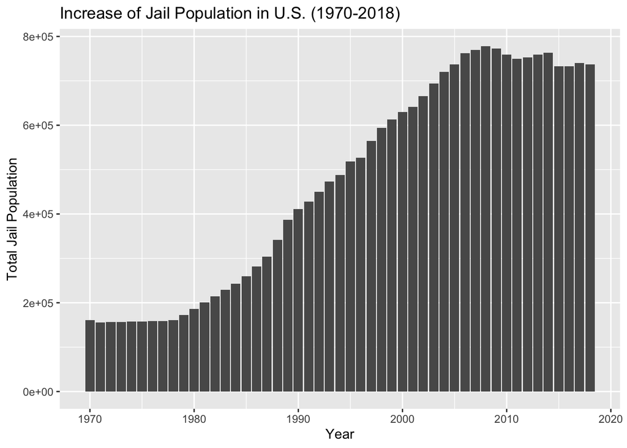

*Figure 1*. Increase of Jail Population in U.S. (1970-2018).  
This chart shows that more people are being incarcerated in the U.S. over time. The number seems to have been stable for the past decade or so, but there was a massive increase from 1980 to 2008.

## Growth of Incarcerated Black and White Populations

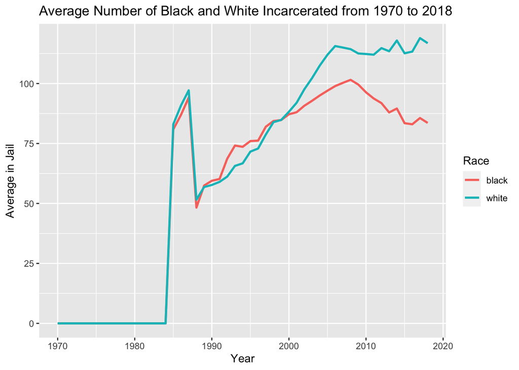

*Figure 3*. Average Number of Black and White Incarcerated (1970-2018).  
This chart shows a relatively equal number of black and white people incarcerated for the most part, despite the much lower black population in the U.S. Recently, the number of black people incarcerated has decreased, but it is still much higher than it would be if the two races were incarcerated at equal rates.

## Map of Black Incarceration in the U.S.

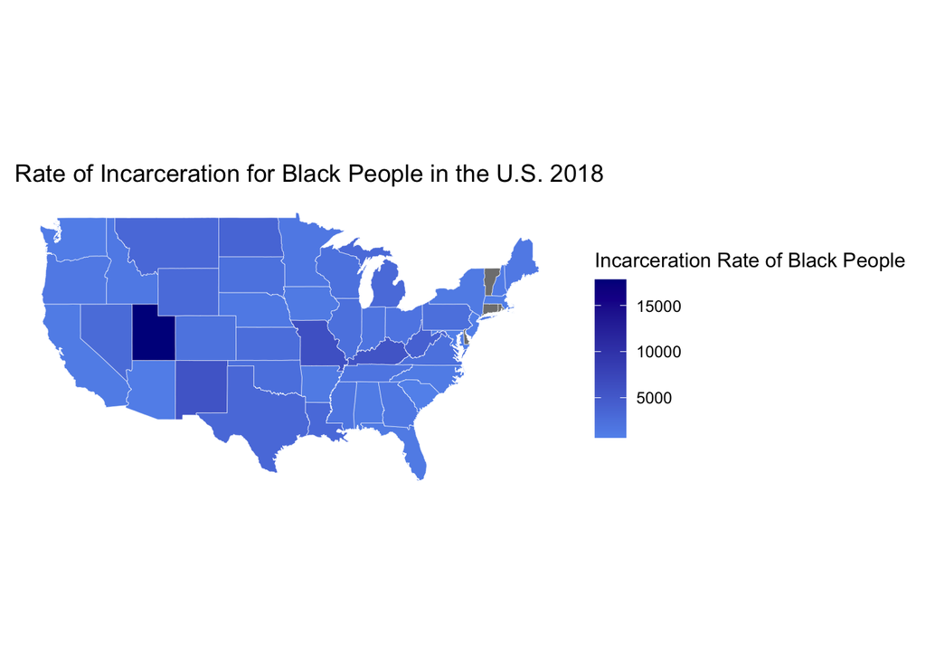